# Modeling_Jack

## Methodology

Since the response variable is continuous, we will use a series of regression models as candidates. We will train a random forest and XGboost because they have proven historically to be excellent at modeling continuous variables. Our EDA pointed us towards some potential clustering in the principle components, so we will train a radial SVM. Our EDA didn’t point us towards any terribly strong linear correlations, and the potential clustering from the EDA makes us want to throw in a KNN model just to be safe.

## Data Preparation

From the *Missing Data* section, we have decided to drop `MFR` and listwise delete observations for `Filler Speed`. Some preliminary modeling showed that `Brand Code` was very responsive to imputation as well. Since the dataset is fairly large and the remaining datapoints seem missing at random, we will drop the remaining observations with missing data.

Our EDA showed that a large number of the predictors were skewed, so we will center and scale the data for models that do not handle skew data or unscaled predictors well, like KNN or SVM. For the ensemble method, we will leave the data as is.

## Partitioning the Data

```r
library(tidymodels)
library(janitor)
library(readxl)
train_data<-as.data.frame(read_xlsx('C:\\Program Files\\GitHub\\predicting_ph\\data\\StudentData.xlsx'))
#removing MFR
train_data<-train_data%>%select(-MFR)%>%mutate(`Brand Code` = as.factor(`Brand Code`))
train_data<-train_data%>%clean_names()
test_data<-read_xlsx('C:\\Program Files\\GitHub\\predicting_ph\\data\\StudentEvaluation.xlsx')
test_data<-test_data%>%select(-MFR)
test_data<-test_data%>%clean_names()
ph_split<-initial_split(train_data%>%na.omit())
ph_train<-training(ph_split)
ph_test<-testing(ph_split)
```

## Data Preprocessing

```r
# create base recipe with missing data handling
base_rec<-
  recipe(ph~., data = ph_train)%>%
  #imputing brand code

  step_impute_bag(brand_code)%>%
  step_unknown(brand_code)%>%
  step_dummy(brand_code)#%>%
  #omitting remaining missing data
  #step_naomit(all_predictors())
temp<-juice(prep(base_rec))
# create centered and scaled data
cs_rec<-
  base_rec%>%
  step_center%>%
  step_scale()

#create resamples
ph_folds<-vfold_cv(ph_train)
```

## Create Models for Tuning

```r
svm_r_spec<-
svm_rbf(cost = tune(), rbf_sigma = tune())%>%
  set_engine('kernlab')%>%
  set_mode('regression')
knn_spec<-
  nearest_neighbor(neighbors = tune(), dist_power = tune(), weight_func = tune())%>%
  set_engine('kknn')%>%
  set_mode('regression')
boost_spec<-
  boost_tree(mtry = tune(), min_n = tune(), trees = 1000)%>%
  set_mode('regression')
rf_spec<-
  rand_forest(mtry = tune(), min_n = tune(), trees = 1000)%>%
  set_engine('ranger', importance = 'impurity')%>%
  set_mode('regression')
```

## Create the workflow set

```r
cc<-
  workflow_set(
    preproc = list(center_scale = cs_rec),
    models  = list(SVM_radial = svm_r_spec, knn_spec)
  )
no_pre_proc<-
  workflow_set(
    preproc = list(base = base_rec),
    models = list(boost = boost_spec, rf = rf_spec)
  )
all_workflows<-
  bind_rows(no_pre_proc, cc)%>%
  mutate(wflow_id = gsub('(center_scale_)|(base_)', '',wflow_id))
```

## Tuning and Evaluating

We will use a racing method to tune the models. This will help us limit the overall computational burden by removing candidate tuning parameters quickly, therefore reducing the total amount of tuned models.

```r
library(finetune)
race_ctrl<-
  control_race(
    save_pred = TRUE,
    parallel_over = 'everything',
    save_workflow = TRUE
  )
race_results_time<-
  system.time(
    race_results<-
      all_workflows%>%
      workflow_map(
        'tune_race_anova',
        seed = 123,
        resamples = ph_folds,
        control = race_ctrl,
        verbose = TRUE
      )
  )
```

```
## i 1 of 4 tuning:     boost
```

```
## i Creating pre-processing data to finalize unknown parameter: mtry
```

```
## v 1 of 4 tuning:     boost (3m 34.9s)
```

```
## i 2 of 4 tuning:     rf
```

```
## i Creating pre-processing data to finalize unknown parameter: mtry
```

```
## v 2 of 4 tuning:     rf (2m 56.5s)
```

```
## i 3 of 4 tuning:     SVM_radial
```

[output not shown]

[output not shown]

[output not shown]

[output not shown]

[output not shown]

[output not shown]

[output not shown]

[output not shown]

[output not shown]

[output not shown]

[output not shown]

[output not shown]

[output not shown]

[output not shown]

[output not shown]

[output not shown]

[output not shown]

[output not shown]

[output not shown]

[output not shown]

[output not shown]

[output not shown]

[output not shown]

[output not shown]

[output not shown]

[output not shown]

[output not shown]

[output not shown]

[output not shown]

[output not shown]

[output not shown]

[output not shown]

[output not shown]

[output not shown]

[output not shown]

[output not shown]

[output not shown]

[output not shown]

[output not shown]

[output not shown]

[output not shown]

[output not shown]

[output not shown]

[output not shown]

```
## v 3 of 4 tuning:     SVM_radial (47.2s)
```

```
## i 4 of 4 tuning:     nearest_neighbor
```

```
## v 4 of 4 tuning:     nearest_neighbor (2m 57.2s)
```

```r
race_results
```

```
## # A workflow set/tibble: 4 x 4
##   wflow_id         info             option    result
##   <chr>            <list>           <list>    <list>
## 1 boost            <tibble [1 x 4]> <opts[2]> <race[+]>
## 2 rf               <tibble [1 x 4]> <opts[2]> <race[+]>
## 3 SVM_radial       <tibble [1 x 4]> <opts[2]> <race[+]>
## 4 nearest_neighbor <tibble [1 x 4]> <opts[2]> <race[+]>
```

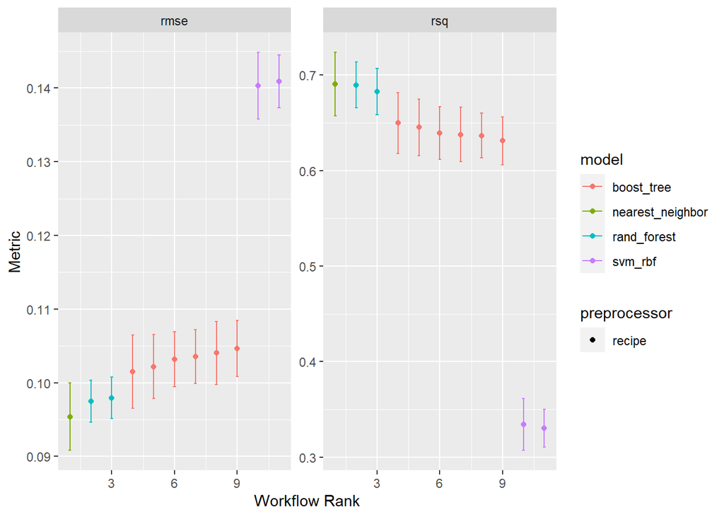

```r
autoplot(race_results)
```

```r
collect_metrics(race_results)
```

```
## # A tibble: 80 x 9
##    wflow_id .config         preproc model .metric .estimator  mean     n std_err
##    <chr>    <chr>           <chr>   <chr> <chr>   <chr>      <dbl> <int>   <dbl>
##  1 boost    Preprocessor1_~ recipe  boos~ rmse    standard   0.102    10 0.00264
##  2 boost    Preprocessor1_~ recipe  boos~ rsq     standard   0.645    10 0.0180
##  3 boost    Preprocessor1_~ recipe  boos~ rmse    standard   0.104    10 0.00223
##  4 boost    Preprocessor1_~ recipe  boos~ rsq     standard   0.638    10 0.0173
##  5 boost    Preprocessor1_~ recipe  boos~ rmse    standard   0.103    10 0.00225
##  6 boost    Preprocessor1_~ recipe  boos~ rsq     standard   0.639    10 0.0168
##  7 boost    Preprocessor1_~ recipe  boos~ rmse    standard   0.105     5 0.00527
##  8 boost    Preprocessor1_~ recipe  boos~ rsq     standard   0.644     5 0.0328
##  9 boost    Preprocessor1_~ recipe  boos~ rmse    standard   0.102     3 0.00452
## 10 boost    Preprocessor1_~ recipe  boos~ rsq     standard   0.649     3 0.00361
## # ... with 70 more rows
```

```r
best_results<-
  race_results%>%
  extract_workflow_set_result('nearest_neighbor')%>%
  select_best(metric = 'rmse')
best_results
```

```
## # A tibble: 1 x 4
##   neighbors weight_func  dist_power .config
##       <int> <chr>             <dbl> <chr>
## 1         8 epanechnikov      0.468 Preprocessor1_Model03
```

```r
knn_test_results<-
  race_results%>%
  extract_workflow('nearest_neighbor')%>%
  finalize_workflow(best_results)%>%
  last_fit(split = ph_split)
collect_metrics(knn_test_results)
```

```
## # A tibble: 2 x 4
##   .metric .estimator .estimate .config
##   <chr>   <chr>          <dbl> <chr>
## 1 rmse    standard      0.0983 Preprocessor1_Model1
## 2 rsq     standard      0.674  Preprocessor1_Model1
```

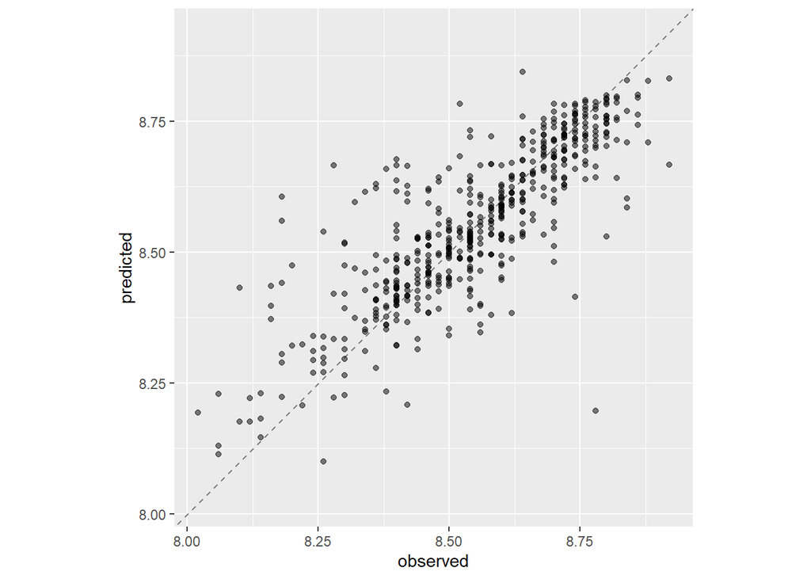

```r
knn_test_results%>%
  collect_predictions()%>%
  ggplot(aes(x = ph, y = .pred))+
  geom_abline(color = 'gray50', lty = 2)+
  geom_point(alpha = .5)+
  coord_obs_pred()+
  labs(x = 'observed', y = 'predicted')
```